# Course Project Prediction

2/11/2021

### 0. Charging all relevant packages

```r
library(corrplot)
library(RColorBrewer)
library(data.table)
library(caret)
library(rpart)
library(kernlab)
library(tree)
library(randomForest)
library(e1071)
```

## 1. Upload raw data

Data source : http://groupware.les.inf.puc-rio.br/har.

```r
setwd('/Users/Lovaniaina/Documents/Coursera.org/Machine learning/')
training = read.table('./Application/pml-training.csv',
                      header = TRUE, sep = ",")

testing = read.table('./Application/pml-testing.csv',
                     header = TRUE, sep = ",")
```

## 2. Format training and test sets

Here we format the “classe” variable of the training set into factor. Then we create a new data frame build on relevant predictors. We decide all sub variables on arm, belt, dumbbell, forearm. To simplify, we don’t use variables which contain NA or missing values.

```r
training$classe = as.factor(training$classe)

dfTraining = data.frame(training$roll_arm,training$pitch_belt,training$yaw_belt,training$gyros_belt_x,
                        training$accel_belt_x,training$magnet_belt_x,
                        training$pitch_arm,training$yaw_arm,training$gyros_arm_x,
                        training$accel_arm_x,training$magnet_arm_x,
                        training$roll_dumbbell,training$pitch_dumbbell,training$yaw_dumbbell,
                        training$gyros_dumbbell_x,training$accel_dumbbell_x,training$magnet_dumbbell_x,
                        training$roll_forearm,training$pitch_forearm,training$yaw_forearm,
                        training$gyros_forearm_x,training$accel_forearm_x,
                        training$magnet_forearm_x,training$classe)

dfTest = data.frame(testing$roll_arm,testing$pitch_belt,testing$yaw_belt,testing$gyros_belt_x,
                    testing$accel_belt_x,testing$magnet_belt_x,
                    testing$pitch_arm,testing$yaw_arm,testing$gyros_arm_x,
                    testing$accel_arm_x,testing$magnet_arm_x,
                    testing$roll_dumbbell,testing$pitch_dumbbell,testing$yaw_dumbbell,
                    testing$gyros_dumbbell_x,testing$accel_dumbbell_x,testing$magnet_dumbbell_x,
                    testing$roll_forearm,testing$pitch_forearm,testing$yaw_forearm,
                    testing$gyros_forearm_x,testing$accel_forearm_x,
                    testing$magnet_forearm_x)

# Renames columns of test set in order to perform prediction
setnames(dfTest, old = c('testing.roll_arm','testing.pitch_belt','testing.yaw_belt','testing.gyros_belt_x',
                    'testing.accel_belt_x','testing.magnet_belt_x',
                    'testing.pitch_arm','testing.yaw_arm','testing.gyros_arm_x',
                    'testing.accel_arm_x','testing.magnet_arm_x',
                    'testing.roll_dumbbell','testing.pitch_dumbbell','testing.yaw_dumbbell',
                    'testing.gyros_dumbbell_x','testing.accel_dumbbell_x','testing.magnet_dumbbell_x',
                    'testing.roll_forearm','testing.pitch_forearm','testing.yaw_forearm',
                    'testing.gyros_forearm_x','testing.accel_forearm_x',
                    'testing.magnet_forearm_x'),
         new = c('training.roll_arm','training.pitch_belt','training.yaw_belt','training.gyros_belt_x',
                    'training.accel_belt_x','training.magnet_belt_x',
                    'training.pitch_arm','training.yaw_arm','training.gyros_arm_x',
                    'training.accel_arm_x','training.magnet_arm_x',
                    'training.roll_dumbbell','training.pitch_dumbbell','training.yaw_dumbbell',
                    'training.gyros_dumbbell_x','training.accel_dumbbell_x','training.magnet_dumbbell_x',
                    'training.roll_forearm','training.pitch_forearm','training.yaw_forearm',
                    'training.gyros_forearm_x','training.accel_forearm_x',
                    'training.magnet_forearm_x'))
```

Here we check that all predictors and data are well formatted (no NA), and get the descriptive statistics of variables.

```r
summary(dfTraining)
```

```
##  training.roll_arm training.pitch_belt training.yaw_belt training.gyros_belt_x
##  Min.   :-180.00   Min.   :-55.8000    Min.   :-180.00   Min.   :-1.040000
##  1st Qu.: -31.77   1st Qu.:  1.7600    1st Qu.: -88.30   1st Qu.:-0.030000
##  Median :   0.00   Median :  5.2800    Median : -13.00   Median : 0.030000
##  Mean   :  17.83   Mean   :  0.3053    Mean   : -11.21   Mean   :-0.005592
##  3rd Qu.:  77.30   3rd Qu.: 14.9000    3rd Qu.:  12.90   3rd Qu.: 0.110000
##  Max.   : 180.00   Max.   : 60.3000    Max.   : 179.00   Max.   : 2.220000
##  training.accel_belt_x training.magnet_belt_x training.pitch_arm
##  Min.   :-120.000      Min.   :-52.0          Min.   :-88.800
##  1st Qu.: -21.000      1st Qu.:  9.0          1st Qu.:-25.900
##  Median : -15.000      Median : 35.0          Median :  0.000
##  Mean   :  -5.595      Mean   : 55.6          Mean   : -4.612
##  3rd Qu.:  -5.000      3rd Qu.: 59.0          3rd Qu.: 11.200
##  Max.   :  85.000      Max.   :485.0          Max.   : 88.500
##  training.yaw_arm    training.gyros_arm_x training.accel_arm_x
##  Min.   :-180.0000   Min.   :-6.37000     Min.   :-404.00
##  1st Qu.: -43.1000   1st Qu.:-1.33000     1st Qu.:-242.00
##  Median :   0.0000   Median : 0.08000     Median : -44.00
##  Mean   :  -0.6188   Mean   : 0.04277     Mean   : -60.24
##  3rd Qu.:  45.8750   3rd Qu.: 1.57000     3rd Qu.:  84.00
##  Max.   : 180.0000   Max.   : 4.87000     Max.   : 437.00
##  training.magnet_arm_x training.roll_dumbbell training.pitch_dumbbell
##  Min.   :-584.0        Min.   :-153.71        Min.   :-149.59
##  1st Qu.:-300.0        1st Qu.: -18.49        1st Qu.: -40.89
##  Median : 289.0        Median :  48.17        Median : -20.96
##  Mean   : 191.7        Mean   :  23.84        Mean   : -10.78
##  3rd Qu.: 637.0        3rd Qu.:  67.61        3rd Qu.:  17.50
##  Max.   : 782.0        Max.   : 153.55        Max.   : 149.40
##  training.yaw_dumbbell training.gyros_dumbbell_x training.accel_dumbbell_x
##  Min.   :-150.871      Min.   :-204.0000         Min.   :-419.00
##  1st Qu.: -77.644      1st Qu.:  -0.0300         1st Qu.: -50.00
##  Median :  -3.324      Median :   0.1300         Median :  -8.00
##  Mean   :   1.674      Mean   :   0.1611         Mean   : -28.62
##  3rd Qu.:  79.643      3rd Qu.:   0.3500         3rd Qu.:  11.00
##  Max.   : 154.952      Max.   :   2.2200         Max.   : 235.00
##  training.magnet_dumbbell_x training.roll_forearm training.pitch_forearm
##  Min.   :-643.0             Min.   :-180.0000     Min.   :-72.50
##  1st Qu.:-535.0             1st Qu.:  -0.7375     1st Qu.:  0.00
##  Median :-479.0             Median :  21.7000     Median :  9.24
##  Mean   :-328.5             Mean   :  33.8265     Mean   : 10.71
##  3rd Qu.:-304.0             3rd Qu.: 140.0000     3rd Qu.: 28.40
##  Max.   : 592.0             Max.   : 180.0000     Max.   : 89.80
##  training.yaw_forearm training.gyros_forearm_x training.accel_forearm_x
##  Min.   :-180.00      Min.   :-22.000          Min.   :-498.00
##  1st Qu.: -68.60      1st Qu.: -0.220          1st Qu.:-178.00
##  Median :   0.00      Median :  0.050          Median : -57.00
##  Mean   :  19.21      Mean   :  0.158          Mean   : -61.65
##  3rd Qu.: 110.00      3rd Qu.:  0.560          3rd Qu.:  76.00
##  Max.   : 180.00      Max.   :  3.970          Max.   : 477.00
##  training.magnet_forearm_x training.classe
##  Min.   :-1280.0           A:5580
##  1st Qu.: -616.0           B:3797
##  Median : -378.0           C:3422
##  Mean   : -312.6           D:3216
##  3rd Qu.:  -73.0           E:3607
##  Max.   :  672.0
```

```r
summary(dfTest)
```

```
##  training.roll_arm training.pitch_belt training.yaw_belt training.gyros_belt_x
##  Min.   :-137.00   Min.   :-41.600     Min.   :-93.70    Min.   :-0.500
##  1st Qu.:   0.00   1st Qu.:  3.013     1st Qu.:-88.62    1st Qu.:-0.070
##  Median :   0.00   Median :  4.655     Median :-87.85    Median : 0.020
##  Mean   :  16.42   Mean   :  5.824     Mean   :-59.30    Mean   :-0.045
##  3rd Qu.:  71.53   3rd Qu.:  6.135     3rd Qu.:-63.50    3rd Qu.: 0.070
##  Max.   : 152.00   Max.   : 27.800     Max.   :162.00    Max.   : 0.240
##  training.accel_belt_x training.magnet_belt_x training.pitch_arm
##  Min.   :-48.00        Min.   :-13.00         Min.   :-63.800
##  1st Qu.:-19.00        1st Qu.:  5.50         1st Qu.: -9.188
##  Median :-13.00        Median : 33.50         Median :  0.000
##  Mean   :-13.50        Mean   : 35.15         Mean   : -3.950
##  3rd Qu.: -8.75        3rd Qu.: 46.25         3rd Qu.:  3.465
##  Max.   : 46.00        Max.   :169.00         Max.   : 55.000
##  training.yaw_arm  training.gyros_arm_x training.accel_arm_x
##  Min.   :-167.00   Min.   :-3.710       Min.   :-341.0
##  1st Qu.: -60.15   1st Qu.:-0.645       1st Qu.:-277.0
##  Median :   0.00   Median : 0.020       Median :-194.5
##  Mean   :  -2.80   Mean   : 0.077       Mean   :-134.6
##  3rd Qu.:  25.50   3rd Qu.: 1.248       3rd Qu.:   5.5
##  Max.   : 178.00   Max.   : 3.660       Max.   : 106.0
##  training.magnet_arm_x training.roll_dumbbell training.pitch_dumbbell
##  Min.   :-428.00       Min.   :-111.118       Min.   :-54.97
##  1st Qu.:-373.75       1st Qu.:   7.494       1st Qu.:-51.89
##  Median :-265.00       Median :  50.403       Median :-40.81
##  Mean   : -38.95       Mean   :  33.760       Mean   :-19.47
##  3rd Qu.: 250.50       3rd Qu.:  58.129       3rd Qu.: 16.12
##  Max.   : 750.00       Max.   : 123.984       Max.   : 96.87
##  training.yaw_dumbbell training.gyros_dumbbell_x training.accel_dumbbell_x
##  Min.   :-103.3200     Min.   :-1.0300           Min.   :-159.00
##  1st Qu.: -75.2809     1st Qu.: 0.1600           1st Qu.:-140.25
##  Median :  -8.2863     Median : 0.3600           Median : -19.00
##  Mean   :  -0.9385     Mean   : 0.2690           Mean   : -47.60
##  3rd Qu.:  55.8335     3rd Qu.: 0.4625           3rd Qu.:  15.75
##  Max.   : 132.2337     Max.   : 1.0600           Max.   : 185.00
##  training.magnet_dumbbell_x training.roll_forearm training.pitch_forearm
##  Min.   :-576.0             Min.   :-176.00       Min.   :-63.500
##  1st Qu.:-528.0             1st Qu.: -40.25       1st Qu.:-11.457
##  Median :-508.5             Median :  94.20       Median :  8.830
##  Mean   :-304.2             Mean   :  38.66       Mean   :  7.099
##  3rd Qu.:-317.0             3rd Qu.: 143.25       3rd Qu.: 28.500
##  Max.   : 523.0             Max.   : 176.00       Max.   : 59.300
##  training.yaw_forearm training.gyros_forearm_x training.accel_forearm_x
##  Min.   :-168.000     Min.   :-1.0600          Min.   :-212.0
##  1st Qu.: -93.375     1st Qu.:-0.5850          1st Qu.:-114.8
##  Median : -19.250     Median : 0.0200          Median :  86.0
##  Mean   :   2.195     Mean   :-0.0200          Mean   :  38.8
##  3rd Qu.: 104.500     3rd Qu.: 0.2925          3rd Qu.: 166.2
##  Max.   : 159.000     Max.   : 1.3800          Max.   : 232.0
##  training.magnet_forearm_x
##  Min.   :-714.0
##  1st Qu.:-427.2
##  Median :-189.5
##  Mean   :-159.2
##  3rd Qu.:  41.5
##  Max.   : 532.0
```

## 3. Plot 1: Correlation matrix between predictors

Here we exclude the dependent variable “classe”.

```r
corrMat = cor(dfTraining[-24]) #
M = head(round(corrMat,2))
M
```

```
##                        training.roll_arm training.pitch_belt training.yaw_belt
## training.roll_arm                   1.00                0.17             -0.34
## training.pitch_belt                 0.17                1.00             -0.70
## training.yaw_belt                  -0.34               -0.70              1.00
## training.gyros_belt_x              -0.25               -0.44              0.15
## training.accel_belt_x              -0.20               -0.97              0.71
## training.magnet_belt_x             -0.21               -0.88              0.74
##                        training.gyros_belt_x training.accel_belt_x
## training.roll_arm                      -0.25                 -0.20
## training.pitch_belt                    -0.44                 -0.97
## training.yaw_belt                       0.15                  0.71
## training.gyros_belt_x                   1.00                  0.47
## training.accel_belt_x                   0.47                  1.00
## training.magnet_belt_x                  0.43                  0.89
##                        training.magnet_belt_x training.pitch_arm
## training.roll_arm                       -0.21              -0.04
## training.pitch_belt                     -0.88              -0.16
## training.yaw_belt                        0.74               0.14
## training.gyros_belt_x                    0.43              -0.03
## training.accel_belt_x                    0.89               0.13
## training.magnet_belt_x                   1.00               0.18
##                        training.yaw_arm training.gyros_arm_x
## training.roll_arm                  0.41                -0.01
## training.pitch_belt                0.14                -0.05
## training.yaw_belt                 -0.23                 0.04
## training.gyros_belt_x             -0.15                 0.06
## training.accel_belt_x             -0.14                 0.06
## training.magnet_belt_x            -0.12                 0.06
##                        training.accel_arm_x training.magnet_arm_x
## training.roll_arm                      0.17                  0.06
## training.pitch_belt                    0.20                 -0.04
## training.yaw_belt                      0.06                  0.08
## training.gyros_belt_x                 -0.37                  0.03
## training.accel_belt_x                 -0.20                  0.04
## training.magnet_belt_x                -0.16                  0.01
##                        training.roll_dumbbell training.pitch_dumbbell
## training.roll_arm                       -0.15                    0.23
## training.pitch_belt                     -0.35                    0.23
## training.yaw_belt                        0.10                   -0.09
## training.gyros_belt_x                    0.25                   -0.20
```

[output cut: 22 more lines]

```
## training.magnet_belt_x                 -0.16                  -0.24
##                        training.yaw_forearm training.gyros_forearm_x
## training.roll_arm                      0.24                    -0.17
## training.pitch_belt                    0.05                    -0.54
## training.yaw_belt                     -0.20                     0.57
## training.gyros_belt_x                 -0.18                     0.13
## training.accel_belt_x                 -0.08                     0.53
## training.magnet_belt_x                -0.03                     0.54
##                        training.accel_forearm_x training.magnet_forearm_x
## training.roll_arm                          0.23                      0.05
## training.pitch_belt                        0.13                     -0.07
## training.yaw_belt                         -0.39                     -0.09
## training.gyros_belt_x                     -0.21                      0.05
## training.accel_belt_x                     -0.17                      0.05
## training.magnet_belt_x                    -0.17                      0.03
```

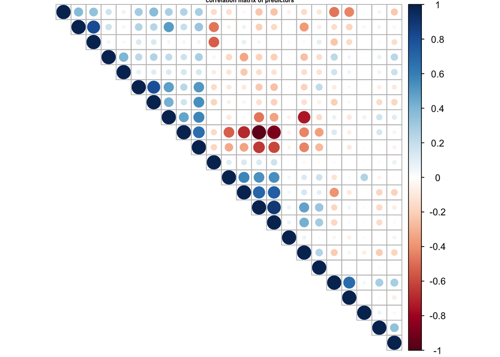

```r
corrplot(corrMat, type="upper", order="hclust",tl.pos='n', main = "correlation matrix of predictors", cex.main = .5,pch = 4, pch.col = "black", pch.cex = 10)
```

As we can see, some variables are correlated, since we have high dimensionality of predictors, one might use PCA to deal with this risk, here we apply PCA just for comprehension and analysis purpose.

## 4. PCA analysis

We can observe that the first two PCs are almost orthogonal i.e. around 0.

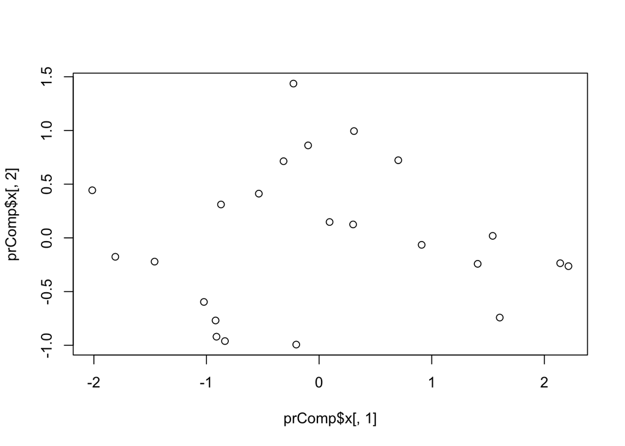

```r
dataPCA <- corrMat
prComp <- prcomp(dataPCA)
plot(prComp$x[,1],prComp$x[,2])
```

```r
# Explore PC1 and PC2
prComp$rotation
```

```
##                                     PC1         PC2           PC3          PC4
## training.roll_arm          -0.166282962  0.07632380 -0.0431468620  0.030687320
## training.pitch_belt        -0.374588169  0.09698362  0.0048971652  0.028262146
## training.yaw_belt           0.268468470 -0.26666766  0.1544924254 -0.242881274
## training.gyros_belt_x       0.253563290 -0.03586914 -0.0771176642  0.435461897
## training.accel_belt_x       0.375533468 -0.11611016  0.0034093181 -0.002369370
## training.magnet_belt_x      0.363205060 -0.10509346  0.0220117166 -0.091037738
## training.pitch_arm          0.107100553  0.19363387  0.4533538921 -0.217165879
## training.yaw_arm           -0.108082509  0.10509788 -0.0593311232  0.034223073
## training.gyros_arm_x        0.038570355  0.01034467 -0.0074491555 -0.005739238
## training.accel_arm_x       -0.173391835 -0.31650607 -0.3817661816 -0.170959613
## training.magnet_arm_x      -0.049668466 -0.34398817 -0.5136609507  0.045743615
## training.roll_dumbbell      0.146583901 -0.04857469 -0.0297581279  0.184900762
## training.pitch_dumbbell    -0.191766859 -0.20892142  0.2884521847  0.219130368
## training.yaw_dumbbell      -0.334220739 -0.08653098  0.1807528446  0.050495502
## training.gyros_dumbbell_x   0.002606413  0.02030267  0.0005422077 -0.202260109
## training.accel_dumbbell_x  -0.173884243 -0.26519519  0.3244042699  0.212657283
## training.magnet_dumbbell_x -0.270185771 -0.09293389  0.1915518569 -0.335456822
## training.roll_forearm      -0.070042330  0.19942821 -0.2042636604 -0.311166967
## training.pitch_forearm     -0.162718673 -0.33770022  0.0155670164 -0.042487530
## training.yaw_forearm       -0.031738560  0.24552223 -0.1420474070 -0.320285883
## training.gyros_forearm_x    0.235187968 -0.10261215  0.0972221441 -0.271202587
## training.accel_forearm_x   -0.055577389  0.42627134 -0.1334971173  0.079981028
## training.magnet_forearm_x   0.039349730  0.28546527 -0.0315494130  0.311580088
##                                     PC5         PC6           PC7          PC8
## training.roll_arm          -0.148765465 -0.56045628  0.0920657662 -0.107826025
## training.pitch_belt         0.195443888  0.17310233  0.0443747622 -0.002121062
## training.yaw_belt          -0.189829800  0.03830546  0.0980184287  0.199730906
## training.gyros_belt_x       0.259992157 -0.03813227  0.0008778879 -0.123686586
## training.accel_belt_x      -0.168733487 -0.17247224 -0.0208123799  0.017426628
## training.magnet_belt_x     -0.157757211 -0.14928309 -0.0021309547  0.059479330
## training.pitch_arm          0.166131443 -0.02034527 -0.0209014629  0.025758559
## training.yaw_arm           -0.079626784 -0.57756941  0.2153165995 -0.106729376
## training.gyros_arm_x        0.220807829 -0.04911767 -0.1253111527  0.543818567
## training.accel_arm_x       -0.204390066  0.05689397  0.0124478790  0.126192804
## training.magnet_arm_x      -0.092736578  0.04188787 -0.0020134722  0.011739845
## training.roll_dumbbell     -0.089153890  0.09043355 -0.6449324661 -0.306584699
## training.pitch_dumbbell    -0.252627196 -0.03562499 -0.3373884598 -0.129392783
## training.yaw_dumbbell      -0.049700927  0.05147529  0.0368958384  0.072904200
## training.gyros_dumbbell_x  -0.021492428  0.24142640  0.3088795140 -0.629509332
```

[output cut: 89 more lines]

```
## training.gyros_arm_x       -0.008010857  0.030778030 -0.016097661
## training.accel_arm_x        0.128846860 -0.698669031  0.021698043
## training.magnet_arm_x      -0.190637610  0.574007465 -0.083311141
## training.roll_dumbbell     -0.087837191 -0.062108734 -0.057616159
## training.pitch_dumbbell     0.023525797  0.016150433  0.010420485
## training.yaw_dumbbell       0.017253749  0.040083369 -0.043515036
## training.gyros_dumbbell_x  -0.010708345  0.007155360 -0.017722226
## training.accel_dumbbell_x  -0.203166296 -0.128236229  0.005635276
## training.magnet_dumbbell_x  0.340472036  0.378976180  0.013174464
## training.roll_forearm      -0.018735384 -0.019669077 -0.014077349
## training.pitch_forearm     -0.024739283 -0.029161049 -0.049799348
## training.yaw_forearm       -0.003083663  0.005125031 -0.040472507
## training.gyros_forearm_x    0.016450706 -0.010373495 -0.016991572
## training.accel_forearm_x   -0.259521077 -0.018875067 -0.103826227
## training.magnet_forearm_x   0.125145714 -0.001261912 -0.012391433
```

## 4. Use train() for model’s fitting

Here I just used some train data set since the computation is costly in my PC when I take all data training size. I decide to choose random forest algorithm as we want to predict categorical variable versus continuous variable. In order to see the precision, we use a second model RF with train control parameter.

```r
set.seed(8)

inTrain = createDataPartition(dfTraining$training.classe, p = 0.10,list = FALSE)
Dtraining = dfTraining[inTrain,]

Dtesting = dfTraining[-inTrain,] # here replaced by the pml-testing.csv

# Alternative sets of PCs
modelFitRF <- train(training.classe ~.,
                    method = 'rf',
                    data = Dtraining,
                    prox = TRUE)

modelFitRF_CV <- train(training.classe ~.,
                    method = 'rf',
                    data = Dtraining,
                    trControl = trainControl(method = 'cv'),
                    number = 3)
```

## 5. Explore the confusion matrix for both models.

Here we can see that both models has a lower classification error for the five factor variables. I assume that if we use all data training, we will get a better classification.

```r
# First model used: Random forest.
modelFitRF$finalModel
```

```
##
## Call:
##  randomForest(x = x, y = y, mtry = param$mtry, proximity = TRUE)
##                Type of random forest: classification
##                      Number of trees: 500
## No. of variables tried at each split: 2
##
##         OOB estimate of  error rate: 7.89%
## Confusion matrix:
##     A   B   C   D   E class.error
## A 544   6   1   6   1  0.02508961
## B  17 338  17   6   2  0.11052632
## C   3  17 315   4   4  0.08163265
## D   5   0  28 285   4  0.11490683
## E   2  14   9   9 327  0.09418283
```

```r
# Second model used: Random forest with cross validation parameter.
modelFitRF_CV$finalModel
```

```
##
## Call:
##  randomForest(x = x, y = y, mtry = param$mtry, number = 3)
##                Type of random forest: classification
##                      Number of trees: 500
## No. of variables tried at each split: 2
##
##         OOB estimate of  error rate: 7.99%
## Confusion matrix:
##     A   B   C   D   E class.error
## A 547   6   1   3   1  0.01971326
## B  21 331  21   4   3  0.12894737
## C   4  16 316   3   4  0.07871720
## D   3   1  26 286   6  0.11180124
## E   2  14   9   9 327  0.09418283
```

## 6. Get the classification tree plot for training set

In this section, we plot the regression tree in order to better understand how we get the leafs and the final nodes.

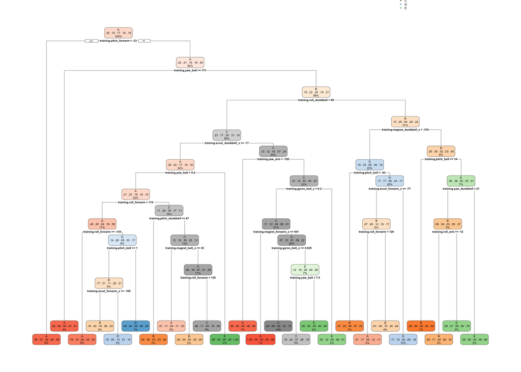

```r
multi.class.model <- rpart(training.classe ~ ., data = Dtraining)
rpart.plot::rpart.plot(multi.class.model)
```

```r
getTree(modelFitRF_CV$finalModel, k = 2)
```

[output not shown]

[output cut: 747 more lines]

## 7.1 Prediction : visualize the prediction

In this section, we perform prediction using test set given. As shown in the graphic below, both models predict the same classification.

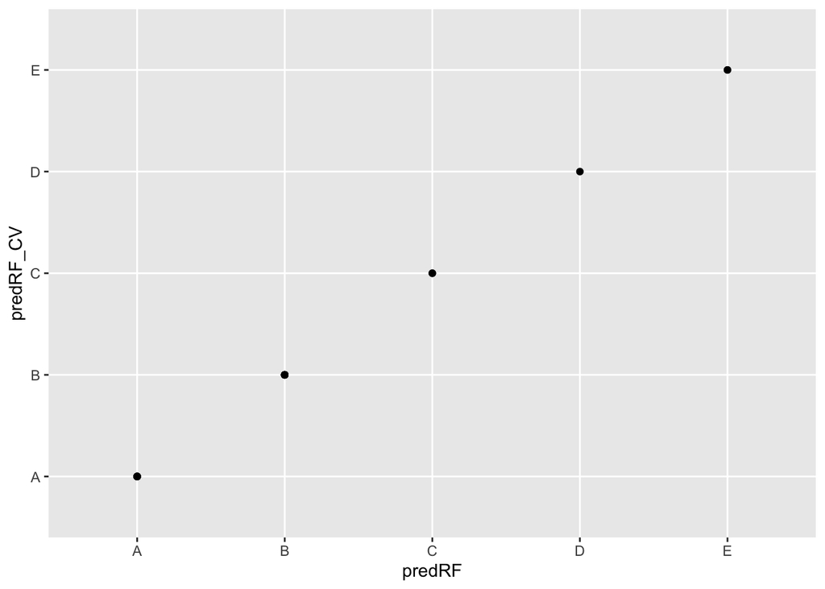

```r
predRF <- predict(modelFitRF, dfTest)
predRF_CV <- predict(modelFitRF_CV, dfTest)

qplot(predRF,predRF_CV, colour = dfTest$classe, data = dfTest)
```

## 7.2 Prediction : Random forest

Here, we just list the classification each of the 20 persons that belong to the test set based on the random forest algorithm.

```r
ClassPredTestRF <- tail(predRF, 20)
ClassPredTestRF
```

```
##  [1] B A B A A C D B A A B C B A E E A B B B
## Levels: A B C D E
```

## 7.3 Prediction : Random forest with training control CV.

Here, we just list the classification each of the 20 persons that belong to the test set based on the random forest algorithm and by adding training control feature Cross validation.

```r
ClassPredTestRF_CV <- tail(predRF_CV, 20)
ClassPredTestRF_CV
```

```
##  [1] B A B A A C D B A A B C B A E E A B B B
## Levels: A B C D E
```

## 8. Summary

Here we just explore how both algorithms classify 20 persons part of the test set. Nothing surprise as random forest works well and both predict the same classification as shown in the previous figure. To sum up, 7 persons will be classified in A, 8 in B, 2 in C and E and 1 in D.

```r
table(ClassPredTestRF,ClassPredTestRF_CV)
```

```
##                ClassPredTestRF_CV
## ClassPredTestRF A B C D E
##               A 7 0 0 0 0
##               B 0 8 0 0 0
##               C 0 0 2 0 0
##               D 0 0 0 1 0
##               E 0 0 0 0 2
```